# Homework 11

Bryan Correa Gonzalez

2025-02-20

## Instructions

Answer the following questions and complete the exercises in RMarkdown. Please embed all of your code and push your final work to your repository. Your final lab report should be organized, clean, and run free from errors. Remember, you must remove the `#` for the included code chunks to run. Be sure to add your name to the author header above.

Make sure to use the formatting conventions of RMarkdown to make your report neat and clean!

## Background

In the `data` folder, you will find data about shark incidents in California between 1950-2022. The [data](https://catalog.data.gov/dataset/shark-incident-database-california-56167) are from: State of California- Shark Incident Database.

## Load the libraries

```r
library("tidyverse")
library("janitor")
library("naniar")
```

## Load the data

Run the following code chunk to import the data.

```r
sharks <- read_csv("data/SharkIncidents_1950_2022_220302.csv") %>% clean_names()
```

## Questions

1. Start by doing some data exploration using your preferred function(s). What is the structure of the data? Where are the missing values and how are they represented?

The missing values are represented as NA’s but there also some “Not counted” in the incident number which will have to be converted to NA.

```r
glimpse(sharks)
```

```
## Rows: 211
## Columns: 16
## $ incident_num     <chr> "1", "2", "3", "4", "5", "6", "7", "8", "9", "10", "1…
## $ month            <dbl> 10, 5, 12, 2, 8, 4, 10, 5, 6, 7, 10, 11, 4, 5, 5, 8, …
## $ day              <dbl> 8, 27, 7, 6, 14, 28, 12, 7, 14, 28, 4, 10, 24, 19, 21…
## $ year             <dbl> 1950, 1952, 1952, 1955, 1956, 1957, 1958, 1959, 1959,…
## $ time             <chr> "12:00", "14:00", "14:00", "12:00", "16:30", "13:30",…
## $ county           <chr> "San Diego", "San Diego", "Monterey", "Monterey", "Sa…
## $ location         <chr> "Imperial Beach", "Imperial Beach", "Lovers Point", "…
## $ mode             <chr> "Swimming", "Swimming", "Swimming", "Freediving", "Sw…
## $ injury           <chr> "major", "minor", "fatal", "minor", "major", "fatal",…
## $ depth            <chr> "surface", "surface", "surface", "surface", "surface"…
## $ species          <chr> "White", "White", "White", "White", "White", "White",…
## $ comment          <chr> "Body Surfing, bit multiple times on leg, thigh and b…
## $ longitude        <chr> "-117.1466667", "-117.2466667", "-122.05", "-122.15",…
## $ latitude         <dbl> 32.58833, 32.58833, 36.62667, 36.62667, 35.13833, 35.…
## $ confirmed_source <chr> "Miller/Collier, Coronado Paper, Oceanside Paper", "G…
## $ wfl_case_number  <chr> NA, NA, NA, NA, NA, NA, NA, NA, NA, NA, NA, NA, NA, N…
```

```r
summary(sharks)
```

```
##  incident_num           month             day             year
##  Length:211         Min.   : 1.000   Min.   : 1.00   Min.   :1950
##  Class :character   1st Qu.: 6.000   1st Qu.: 7.50   1st Qu.:1985
##  Mode  :character   Median : 8.000   Median :18.00   Median :2004
##                     Mean   : 7.858   Mean   :16.54   Mean   :1998
##                     3rd Qu.:10.000   3rd Qu.:25.00   3rd Qu.:2014
##                     Max.   :12.000   Max.   :31.00   Max.   :2022
##
##      time              county            location             mode
##  Length:211         Length:211         Length:211         Length:211
##  Class :character   Class :character   Class :character   Class :character
##  Mode  :character   Mode  :character   Mode  :character   Mode  :character
##
##
##
##
##     injury             depth             species            comment
##  Length:211         Length:211         Length:211         Length:211
##  Class :character   Class :character   Class :character   Class :character
##  Mode  :character   Mode  :character   Mode  :character   Mode  :character
##
##
##
##
##   longitude            latitude     confirmed_source   wfl_case_number
##  Length:211         Min.   :32.59   Length:211         Length:211
##  Class :character   1st Qu.:34.04   Class :character   Class :character
##  Mode  :character   Median :36.70   Mode  :character   Mode  :character
##                     Mean   :36.36
##                     3rd Qu.:38.18
##                     Max.   :41.56
##                     NA's   :6
```

```r
miss_var_summary(sharks)
```

```
## # A tibble: 16 × 3
##    variable         n_miss pct_miss
##    <chr>             <int>    <num>
##  1 wfl_case_number     202   95.7
##  2 time                  7    3.32
##  3 latitude              6    2.84
##  4 longitude             5    2.37
##  5 confirmed_source      1    0.474
##  6 incident_num          0    0
##  7 month                 0    0
##  8 day                   0    0
##  9 year                  0    0
## 10 county                0    0
## 11 location              0    0
## 12 mode                  0    0
## 13 injury                0    0
## 14 depth                 0    0
## 15 species               0    0
## 16 comment               0    0
```

2. Notice that there are some incidents identified as “NOT COUNTED”. These should be removed from the data because they were either not sharks, unverified, or were provoked. It’s OK to replace the `sharks` object.

```r
sharks <- sharks %>%
  filter(incident_num != "NOT COUNTED")
```

3. Are there any “hotspots” for shark incidents in California? Make a table and plot that shows the total number of incidents per county. Which county has the highest number of incidents?

The county with the highest number of incidents is San Diego.

```r
sharks %>%
  select(incident_num, county) %>%
  group_by(county) %>%
  summarize(n_incident = n_distinct(incident_num)) %>%
  arrange(desc(n_incident))
```

```
## # A tibble: 21 × 2
##    county          n_incident
##    <chr>                <int>
##  1 San Diego               23
##  2 Santa Barbara           19
##  3 Humboldt                18
##  4 San Mateo               18
##  5 Marin                   16
##  6 Monterey                15
##  7 Santa Cruz              15
##  8 Sonoma                  15
##  9 San Luis Obispo         14
## 10 Los Angeles              9
## # ℹ 11 more rows
```

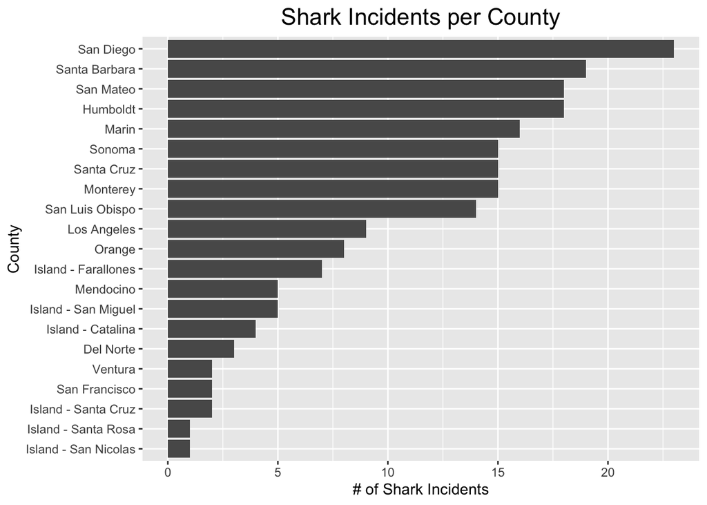

```r
sharks %>%
  select(incident_num, county) %>%
  group_by(county) %>%
  summarize(n_incident = n_distinct(incident_num)) %>%
  ggplot(aes(x=reorder(county,n_incident), y=n_incident)) +
  geom_col()+
  labs(,title= "Shark Incidents per County",
       x="County",
       y= "# of Shark Incidents") +
  theme(plot.title=element_text(size=rel(1.5),hjust=0.5))+
  coord_flip()
```

4. Are there months of the year when incidents are more likely to occur? Make a table and a plot that shows the total number of incidents by month. Which month has the highest number of incidents?

October has the highest number of incidents.

```r
sharks %>%
  select(incident_num, month) %>%
  group_by(month) %>%
  summarize(n_incident = n_distinct(incident_num)) %>%
  arrange(desc(n_incident))
```

```
## # A tibble: 12 × 2
##    month n_incident
##    <dbl>      <int>
##  1    10         36
##  2     8         31
##  3     9         31
##  4     7         23
##  5     5         16
##  6    11         16
##  7     6         14
##  8    12         13
##  9     1          7
## 10     4          6
## 11     3          5
## 12     2          4
```

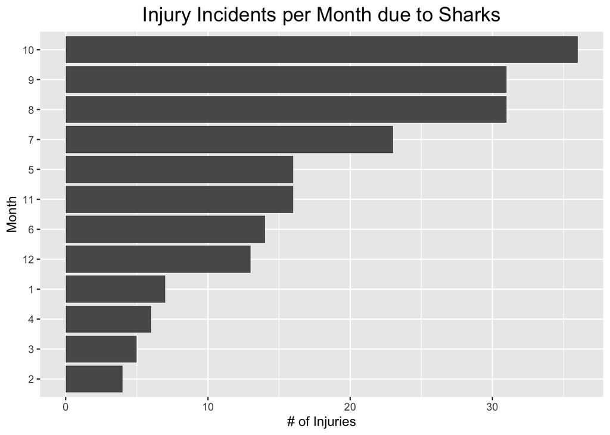

```r
sharks %>%
  mutate(month = as.character(month)) %>%
  select(incident_num, month) %>%
  group_by(month) %>%
  summarize(n_incident = n_distinct(incident_num)) %>%
  ggplot(aes(x=reorder(month, n_incident), y=n_incident))+
  geom_col()+
  labs(,title= "Injury Incidents per Month due to Sharks",
       x="Month",
       y= "# of Injuries") +
  theme(plot.title=element_text(size=rel(1.5),hjust=0.5))+
  coord_flip()
```

5. How do the number and types of injuries compare by county? Make a table that shows the number of injury types by county. Which county has the highest number incidents?

San Diego has the most incidents that involved an injury with a total of 14 incidents.

```r
shark_injury_by_county <- sharks %>%
  select(county, injury) %>%
  filter(injury != "none") %>%
  group_by(county, injury) %>%
  summarise(total=n(), .groups = 'keep') %>%
  pivot_wider(names_from = injury,
              values_from = total) %>%
  mutate(total=sum(minor, major, fatal, na.rm=T)) %>%
  arrange(desc(total))
shark_injury_by_county
```

```
## # A tibble: 21 × 5
## # Groups:   county [21]
##    county              minor major fatal total
##    <chr>               <int> <int> <int> <int>
##  1 San Diego               8     4     2    14
##  2 Marin                   4     9    NA    13
##  3 Monterey                2     8     2    12
##  4 Santa Barbara           6     2     2    10
##  5 Humboldt                2     7    NA     9
##  6 Sonoma                  1     8    NA     9
##  7 Island - Farallones    NA     7    NA     7
##  8 Los Angeles             6    NA     1     7
##  9 San Luis Obispo         1     3     3     7
## 10 Santa Cruz              3     3     1     7
## # ℹ 11 more rows
```

6. Use the table from #5 to make a plot that shows the total number of incidents by county.

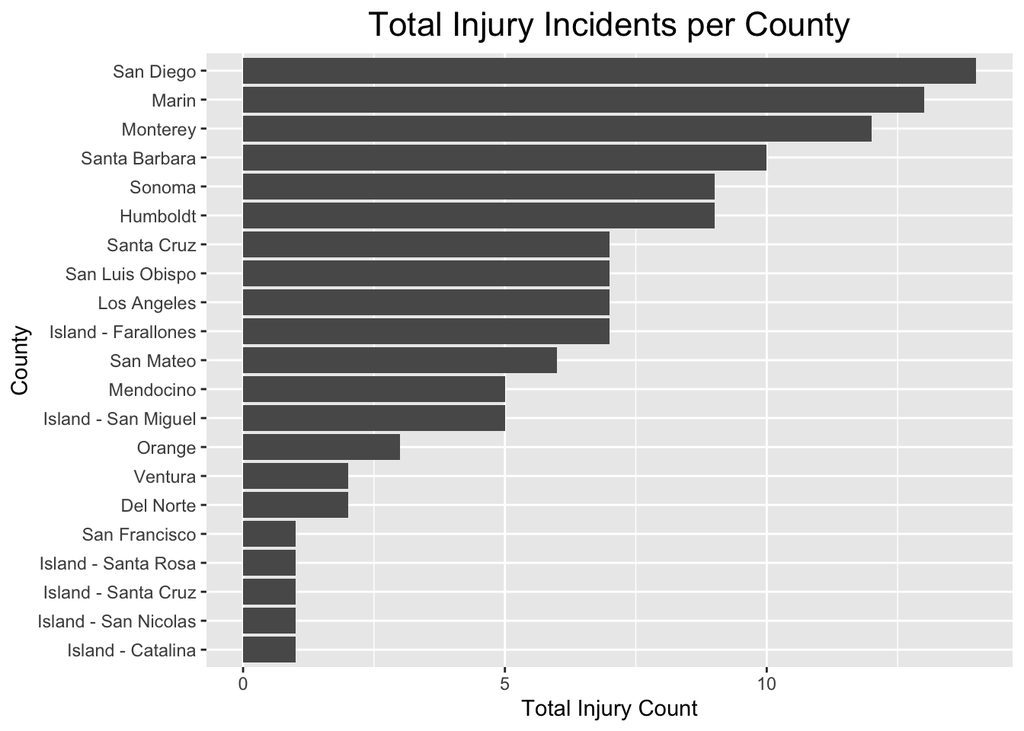

```r
shark_injury_by_county %>%
  ggplot(aes(x=reorder(county,total), y=total))+
  geom_col()+
  labs(title= "Total Injury Incidents per County",
       x="County",
       y= "Total Injury Count") +
  theme(plot.title=element_text(size=rel(1.5),hjust=0.5))+
  coord_flip()
```

7. In the data, `mode` refers to a type of activity. Which activity is associated with the highest number of incidents?

Surfing/Boarding has the highest number of incidents.

```r
sharks %>%
  select(incident_num, mode) %>%
  group_by(mode) %>%
  summarize(n_injuries = n_distinct(incident_num)) %>%
  arrange(desc(n_injuries))
```

```
## # A tibble: 7 × 2
##   mode                n_injuries
##   <chr>                    <int>
## 1 Surfing / Boarding          80
## 2 Freediving                  35
## 3 Kayaking / Canoeing         29
## 4 Swimming                    22
## 5 Scuba Diving                19
## 6 Hookah Diving               10
## 7 Paddleboarding               7
```

8. Make a plot that compares the number of incidents by activity.

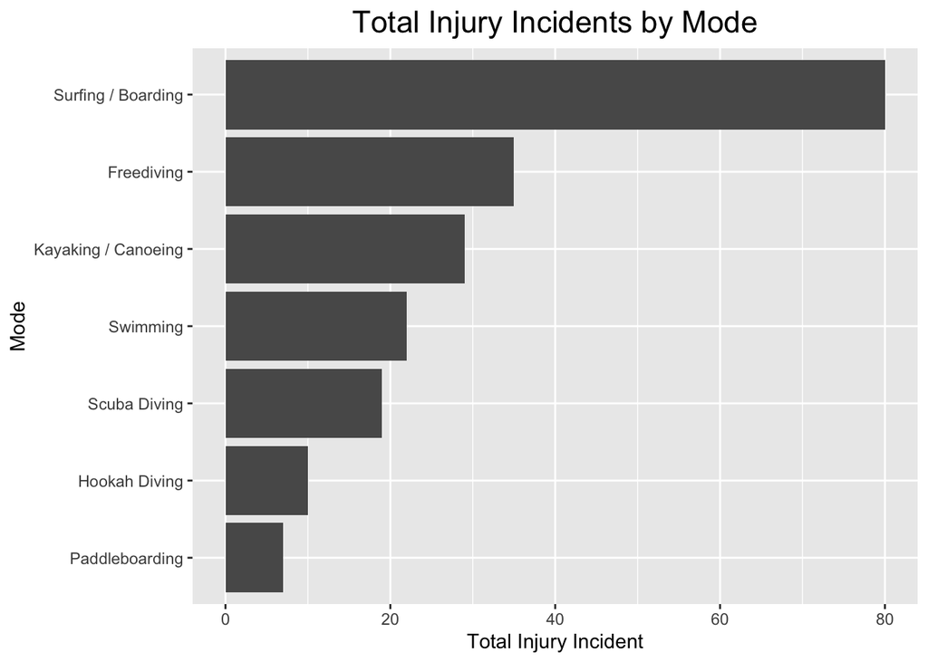

```r
sharks %>%
  select(incident_num, mode) %>%
  group_by(mode) %>%
  summarize(n_injuries = n_distinct(incident_num)) %>%
  ggplot(aes(x=reorder(mode, n_injuries), y=(n_injuries))) +
   geom_col()+
  labs(,title= "Total Injury Incidents by Mode",
       x="Mode",
       y= "Total Injury Incident") +
  theme(plot.title=element_text(size=rel(1.5),hjust=0.5))+
  coord_flip()
```

9. Which shark species is involved in the highest number of incidents?

Great White Sharks.

```r
sharks %>%
  select(incident_num, species) %>%
  group_by(species) %>%
  summarize(n_incident = n_distinct(incident_num)) %>%
  arrange(desc(n_incident))
```

```
## # A tibble: 8 × 2
##   species    n_incident
##   <chr>           <int>
## 1 White             179
## 2 Unknown            13
## 3 Hammerhead          3
## 4 Blue                2
## 5 Leopard             2
## 6 Salmon              1
## 7 Sevengill           1
## 8 Thresher            1
```

10. Are all incidents involving Great White’s fatal? Make a plot that shows the number and types of incidents for Great White’s only.

```r
sharks %>%
  select(incident_num, species, injury) %>%
  filter(species == "White") %>%
  group_by(injury) %>%
  summarize(n_incident = n_distinct(incident_num)) %>%
  arrange(desc(n_incident))
```

```
## # A tibble: 4 × 2
##   injury n_incident
##   <chr>       <int>
## 1 none           74
## 2 major          59
## 3 minor          31
## 4 fatal          15
```

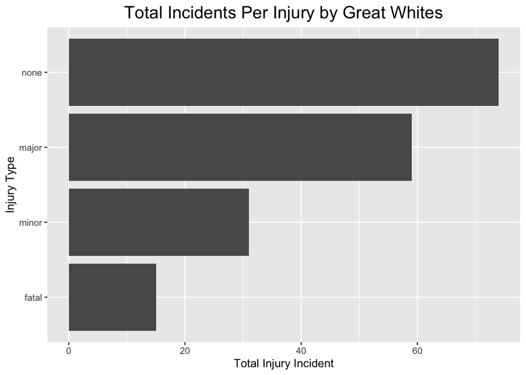

```r
sharks %>%
  select(incident_num, species, injury) %>%
  filter(species == "White") %>%
  group_by(injury) %>%
  summarize(n_incident = n_distinct(incident_num)) %>%
  ggplot(aes(x=reorder(injury, n_incident), y=n_incident)) +
  geom_col()+
  labs(,title= "Total Incidents Per Injury by Great Whites",
       x="Injury Type",
       y= "Total Injury Incident") +
  theme(plot.title=element_text(size=rel(1.5),hjust=0.5))+
  coord_flip()
```